# Binomial Regression

Anil

#BINOMIAL REGRESSION

```r
library(ggplot2)
library(dplyr)
library(tidyverse)
library(broom)
library(fastDummies)
library(magrittr)
library(car)
library(psych)
library(caret)
library(gridExtra)
rawdata <- read.csv('C:/Myfolder/SyntheticData/SynData.csv')
str(rawdata)
```

```
## 'data.frame':    1048575 obs. of  11 variables:
##  $ Step          : int  1 1 1 1 1 1 1 1 1 1 ...
##  $ Type          : Factor w/ 5 levels "CASH_IN","CASH_OUT",..: 4 4 5 2 4 4 4 4 4 3 ...
##  $ Amt           : num  9840 1864 181 181 11668 ...
##  $ NameOrig      : Factor w/ 1048317 levels "C1000001725",..: 125165 361320 165237 961663 567916 994158 298038 494238 143414 891803 ...
##  $ OldBalanceOrig: num  170136 21249 181 181 41554 ...
##  $ NewBalanceOrig: num  160296 19385 0 0 29886 ...
##  $ NameDest      : Factor w/ 449635 levels "C1000015936",..: 274918 286717 73551 65465 138002 371072 340846 381943 128187 47318 ...
##  $ OldBalanceDest: num  0 0 0 21182 0 ...
##  $ NewBalanceDest: num  0 0 0 0 0 ...
##  $ isFraud       : int  0 0 1 1 0 0 0 0 0 0 ...
##  $ isFlaggedFraud: int  0 0 0 0 0 0 0 0 0 0 ...
```

```r
#Descriptive Statistics
summary(rawdata)
```

```
##       Step             Type             Amt
##  Min.   : 1.00   CASH_IN :227130   Min.   :       0
##  1st Qu.:15.00   CASH_OUT:373641   1st Qu.:   12149
##  Median :20.00   DEBIT   :  7178   Median :   76343
##  Mean   :26.97   PAYMENT :353873   Mean   :  158667
##  3rd Qu.:39.00   TRANSFER: 86753   3rd Qu.:  213762
##  Max.   :95.00                     Max.   :10000000
##
##         NameOrig       OldBalanceOrig     NewBalanceOrig
##  C1026010130:      2   Min.   :       0   Min.   :       0
##  C1028315484:      2   1st Qu.:       0   1st Qu.:       0
##  C1039623203:      2   Median :   16002   Median :       0
##  C1041466144:      2   Mean   :  874010   Mean   :  893809
##  C1052471021:      2   3rd Qu.:  136642   3rd Qu.:  174600
##  C1056260641:      2   Max.   :38900000   Max.   :38900000
##  (Other)    :1048563
##         NameDest       OldBalanceDest     NewBalanceDest
##  C985934102 :     98   Min.   :       0   Min.   :       0
##  C1286084959:     96   1st Qu.:       0   1st Qu.:       0
##  C1590550415:     89   Median :  126377   Median :  218260
##  C248609774 :     88   Mean   :  978160   Mean   : 1114198
##  C665576141 :     87   3rd Qu.:  915923   3rd Qu.: 1149808
##  C2083562754:     86   Max.   :42100000   Max.   :42200000
##  (Other)    :1048031
##     isFraud         isFlaggedFraud
##  Min.   :0.000000   Min.   :0
##  1st Qu.:0.000000   1st Qu.:0
##  Median :0.000000   Median :0
##  Mean   :0.001089   Mean   :0
##  3rd Qu.:0.000000   3rd Qu.:0
##  Max.   :1.000000   Max.   :0
##
```

```r
#Missing values
colSums(is.na(rawdata))
```

```
##           Step           Type            Amt       NameOrig OldBalanceOrig
##              0              0              0              0              0
## NewBalanceOrig       NameDest OldBalanceDest NewBalanceDest        isFraud
##              0              0              0              0              0
## isFlaggedFraud
##              0
```

```r
#two-way contingency table of two factor variables
xtabs(~isFraud + Type, rawdata)
```

```
##        Type
## isFraud CASH_IN CASH_OUT  DEBIT PAYMENT TRANSFER
##       0  227130   373063   7178  353873    86189
##       1       0      578      0       0      564
```

As we had seen earlier in EDA that fraud transactions took place only from CASH_OUT & TRANSFER transactions, hence excluding CASH_IN, DEBIT, PAYMENT type transactions for further analysis.

```r
#excluding CASH_IN, DEBIT, PAYMENT transactions for further analysis
rawdata.filt <- rawdata %>% filter(Type %in% c('CASH_OUT', 'TRANSFER'))
str(rawdata.filt)
```

```
## 'data.frame':    460394 obs. of  11 variables:
##  $ Step          : int  1 1 1 1 1 1 1 1 1 1 ...
##  $ Type          : Factor w/ 5 levels "CASH_IN","CASH_OUT",..: 5 2 2 5 5 2 2 2 2 5 ...
##  $ Amt           : num  181 181 229134 215310 311686 ...
##  $ NameOrig      : Factor w/ 1048317 levels "C1000001725",..: 165237 961663 996646 363666 532974 922426 309157 783132 580686 528692 ...
##  $ OldBalanceOrig: num  181 181 15325 705 10835 ...
##  $ NewBalanceOrig: num  0 0 0 0 0 ...
##  $ NameDest      : Factor w/ 449635 levels "C1000015936",..: 73551 65465 69742 4944 92471 25059 87079 58486 49534 46420 ...
##  $ OldBalanceDest: num  0 21182 5083 22425 6267 ...
##  $ NewBalanceDest: num  0 0 51513 0 2719173 ...
##  $ isFraud       : int  1 1 0 0 0 0 0 0 0 0 ...
##  $ isFlaggedFraud: int  0 0 0 0 0 0 0 0 0 0 ...
```

After excluding, now the dataset has 460394 transactions.

```r
#dropping NameOrig and NameDest variables
rawdata.filt.subset <- rawdata.filt[,-c(4,7)]
str(rawdata.filt.subset)
```

```
## 'data.frame':    460394 obs. of  9 variables:
##  $ Step          : int  1 1 1 1 1 1 1 1 1 1 ...
##  $ Type          : Factor w/ 5 levels "CASH_IN","CASH_OUT",..: 5 2 2 5 5 2 2 2 2 5 ...
##  $ Amt           : num  181 181 229134 215310 311686 ...
##  $ OldBalanceOrig: num  181 181 15325 705 10835 ...
##  $ NewBalanceOrig: num  0 0 0 0 0 ...
##  $ OldBalanceDest: num  0 21182 5083 22425 6267 ...
##  $ NewBalanceDest: num  0 0 51513 0 2719173 ...
##  $ isFraud       : int  1 1 0 0 0 0 0 0 0 0 ...
##  $ isFlaggedFraud: int  0 0 0 0 0 0 0 0 0 0 ...
```

```r
#One-hot encoding for Type variable
rawdata.filt.subset.dum <- dummy_cols(rawdata.filt.subset)
str(rawdata.filt.subset.dum)
```

```
## 'data.frame':    460394 obs. of  14 variables:
##  $ Step          : int  1 1 1 1 1 1 1 1 1 1 ...
##  $ Type          : Factor w/ 5 levels "CASH_IN","CASH_OUT",..: 5 2 2 5 5 2 2 2 2 5 ...
##  $ Amt           : num  181 181 229134 215310 311686 ...
##  $ OldBalanceOrig: num  181 181 15325 705 10835 ...
##  $ NewBalanceOrig: num  0 0 0 0 0 ...
##  $ OldBalanceDest: num  0 21182 5083 22425 6267 ...
##  $ NewBalanceDest: num  0 0 51513 0 2719173 ...
##  $ isFraud       : int  1 1 0 0 0 0 0 0 0 0 ...
##  $ isFlaggedFraud: int  0 0 0 0 0 0 0 0 0 0 ...
##  $ Type_CASH_IN  : int  0 0 0 0 0 0 0 0 0 0 ...
##  $ Type_CASH_OUT : int  0 1 1 0 0 1 1 1 1 0 ...
##  $ Type_DEBIT    : int  0 0 0 0 0 0 0 0 0 0 ...
##  $ Type_PAYMENT  : int  0 0 0 0 0 0 0 0 0 0 ...
##  $ Type_TRANSFER : int  1 0 0 1 1 0 0 0 0 1 ...
```

Created dummy variables for Type feature.

```r
#dropping Type variable, as dummy variables were created
final.rawdata <- rawdata.filt.subset.dum %>% select(-c(Type,Type_CASH_IN,Type_DEBIT, Type_PAYMENT,isFlaggedFraud))
str(final.rawdata)
```

```
## 'data.frame':    460394 obs. of  9 variables:
##  $ Step          : int  1 1 1 1 1 1 1 1 1 1 ...
##  $ Amt           : num  181 181 229134 215310 311686 ...
##  $ OldBalanceOrig: num  181 181 15325 705 10835 ...
##  $ NewBalanceOrig: num  0 0 0 0 0 ...
##  $ OldBalanceDest: num  0 21182 5083 22425 6267 ...
##  $ NewBalanceDest: num  0 0 51513 0 2719173 ...
##  $ isFraud       : int  1 1 0 0 0 0 0 0 0 0 ...
##  $ Type_CASH_OUT : int  0 1 1 0 0 1 1 1 1 0 ...
##  $ Type_TRANSFER : int  1 0 0 1 1 0 0 0 0 1 ...
```

```r
#converting step feature into hour format
final.rawdata$hour <- mod(final.rawdata$Step, 24)
str(final.rawdata)
```

```
## 'data.frame':    460394 obs. of  10 variables:
##  $ Step          : int  1 1 1 1 1 1 1 1 1 1 ...
##  $ Amt           : num  181 181 229134 215310 311686 ...
##  $ OldBalanceOrig: num  181 181 15325 705 10835 ...
##  $ NewBalanceOrig: num  0 0 0 0 0 ...
##  $ OldBalanceDest: num  0 21182 5083 22425 6267 ...
##  $ NewBalanceDest: num  0 0 51513 0 2719173 ...
##  $ isFraud       : int  1 1 0 0 0 0 0 0 0 0 ...
##  $ Type_CASH_OUT : int  0 1 1 0 0 1 1 1 1 0 ...
##  $ Type_TRANSFER : int  1 0 0 1 1 0 0 0 0 1 ...
##  $ hour          : num  1 1 1 1 1 1 1 1 1 1 ...
```

```r
#No. of transactions on an hour basis
table(final.rawdata$hour)
```

```
##
##     0     1     2     3     4     5     6     7     8     9    10    11
##  2306  1150   325   132   135   115   358  1941  8154 26310 29358 29174
##    12    13    14    15    16    17    18    19    20    21    22    23
## 35091 33110 33989 31553 35784 37104 42489 44986 34472 15996 11280  5082
```

```r
#dropping step feature
final.rawdata$Step <- NULL
str(final.rawdata)
```

```
## 'data.frame':    460394 obs. of  9 variables:
##  $ Amt           : num  181 181 229134 215310 311686 ...
##  $ OldBalanceOrig: num  181 181 15325 705 10835 ...
##  $ NewBalanceOrig: num  0 0 0 0 0 ...
##  $ OldBalanceDest: num  0 21182 5083 22425 6267 ...
##  $ NewBalanceDest: num  0 0 51513 0 2719173 ...
##  $ isFraud       : int  1 1 0 0 0 0 0 0 0 0 ...
##  $ Type_CASH_OUT : int  0 1 1 0 0 1 1 1 1 0 ...
##  $ Type_TRANSFER : int  1 0 0 1 1 0 0 0 0 1 ...
##  $ hour          : num  1 1 1 1 1 1 1 1 1 1 ...
```

```r
xtabs(~isFraud + hour, final.rawdata)
```

```
##        hour
## isFraud     0     1     2     3     4     5     6     7     8     9    10
##       0  2276  1104   277    98   109    85   314  1895  8102 26263 29295
##       1    30    46    48    34    26    30    44    46    52    47    63
##        hour
## isFraud    11    12    13    14    15    16    17    18    19    20    21
##       0 29120 35030 33055 33935 31507 35734 37059 42419 44948 34432 15939
##       1    54    61    55    54    46    50    45    70    38    40    57
##        hour
## isFraud    22    23
##       0 11225  5031
##       1    55    51
```

```r
#converting isFraud into factor variable
final.rawdata$isFraud <- as.factor(final.rawdata$isFraud)
str(final.rawdata)
```

```
## 'data.frame':    460394 obs. of  9 variables:
##  $ Amt           : num  181 181 229134 215310 311686 ...
##  $ OldBalanceOrig: num  181 181 15325 705 10835 ...
##  $ NewBalanceOrig: num  0 0 0 0 0 ...
##  $ OldBalanceDest: num  0 21182 5083 22425 6267 ...
##  $ NewBalanceDest: num  0 0 51513 0 2719173 ...
##  $ isFraud       : Factor w/ 2 levels "0","1": 2 2 1 1 1 1 1 1 1 1 ...
##  $ Type_CASH_OUT : int  0 1 1 0 0 1 1 1 1 0 ...
##  $ Type_TRANSFER : int  1 0 0 1 1 0 0 0 0 1 ...
##  $ hour          : num  1 1 1 1 1 1 1 1 1 1 ...
```

```r
#class imbalance
table(final.rawdata$isFraud)
```

```
##
##      0      1
## 459252   1142
```

Clearly, there is a class bias, a condition observed when the proportion of events is much smaller than proportion of non-events. There are many ways to deal with class imbalance but will build model as is.

##Correlation plot

```r
#Correlation matrix
round(cor(final.rawdata[-c(6)]), 3)
```

```
##                   Amt OldBalanceOrig NewBalanceOrig OldBalanceDest
## Amt             1.000          0.191         -0.033          0.124
## OldBalanceOrig  0.191          1.000          0.796         -0.024
## NewBalanceOrig -0.033          0.796          1.000         -0.013
## OldBalanceDest  0.124         -0.024         -0.013          1.000
## NewBalanceDest  0.243         -0.010         -0.017          0.976
## Type_CASH_OUT  -0.504         -0.010          0.031         -0.086
## Type_TRANSFER   0.504          0.010         -0.031          0.086
## hour           -0.103         -0.055         -0.044         -0.003
##                NewBalanceDest Type_CASH_OUT Type_TRANSFER   hour
## Amt                     0.243        -0.504         0.504 -0.103
## OldBalanceOrig         -0.010        -0.010         0.010 -0.055
## NewBalanceOrig         -0.017         0.031        -0.031 -0.044
## OldBalanceDest          0.976        -0.086         0.086 -0.003
## NewBalanceDest          1.000        -0.147         0.147 -0.035
## Type_CASH_OUT          -0.147         1.000        -1.000  0.019
## Type_TRANSFER           0.147        -1.000         1.000 -0.019
## hour                   -0.035         0.019        -0.019  1.000
```

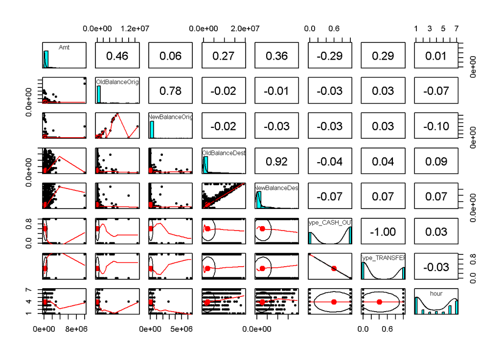

```r
#correlation plot
#pairs.panels(final.rawdata[-c(6)])
samp <- final.rawdata[1:2000,]
pairs.panels(samp[-c(6)])
```

Note: Reduced the dataset size as it was taking long time to run the code with all observations.

The above correlation plot shows that there is a significant correlation between variables ‘OldBalanceOrig’ and ‘NewBalanceOrig’; ‘OldBalanceDest’ and ‘NewBalanceDest’; and ‘Type_CASH_OUT’ and ‘Type_TRANSFER.’ We can make use of Variance Inflation Factor to assess whether these correlations are statistically significant or not.

```r
#Binomial regression
full <- glm(isFraud ~ ., data=final.rawdata, family = "binomial")
summary(full)
```

```
##
## Call:
## glm(formula = isFraud ~ ., family = "binomial", data = final.rawdata)
##
## Deviance Residuals:
##     Min       1Q   Median       3Q      Max
## -4.8197  -0.0302  -0.0052  -0.0004   8.4904
##
## Coefficients: (1 not defined because of singularities)
##                  Estimate Std. Error z value Pr(>|z|)
## (Intercept)    -1.539e+00  1.245e-01  -12.36   <2e-16 ***
## Amt            -3.459e-05  1.715e-06  -20.17   <2e-16 ***
## OldBalanceOrig  4.232e-05  1.708e-06   24.77   <2e-16 ***
## NewBalanceOrig -5.177e-05  1.925e-06  -26.90   <2e-16 ***
## OldBalanceDest  1.811e-06  1.480e-07   12.24   <2e-16 ***
## NewBalanceDest -2.304e-06  1.459e-07  -15.79   <2e-16 ***
## Type_CASH_OUT  -1.650e+00  8.180e-02  -20.17   <2e-16 ***
## Type_TRANSFER          NA         NA      NA       NA
## hour           -1.212e-01  7.736e-03  -15.66   <2e-16 ***
## ---
## Signif. codes:  0 '***' 0.001 '**' 0.01 '*' 0.05 '.' 0.1 ' ' 1
##
## (Dispersion parameter for binomial family taken to be 1)
##
##     Null deviance: 15983.6  on 460393  degrees of freedom
## Residual deviance:  6913.9  on 460386  degrees of freedom
## AIC: 6929.9
##
## Number of Fisher Scoring iterations: 15
```

The summary of the model shows all the features in the model are significant to the model.

Type_TRANSFER variable was not defined because of singularity means that the variable is not linearly independent. This is because the information given by this variable is already contained in the other variable, and thus redundant.

Even if we remove the Type_TRANSFER variable from the above model, will obtain the same result for the rest of the variables.

```r
full1 <- glm(isFraud ~ .-Type_TRANSFER, data=final.rawdata, family = "binomial")
summary(full1)
```

```
##
## Call:
## glm(formula = isFraud ~ . - Type_TRANSFER, family = "binomial",
##     data = final.rawdata)
##
## Deviance Residuals:
##     Min       1Q   Median       3Q      Max
## -4.8197  -0.0302  -0.0052  -0.0004   8.4904
##
## Coefficients:
##                  Estimate Std. Error z value Pr(>|z|)
## (Intercept)    -1.539e+00  1.245e-01  -12.36   <2e-16 ***
## Amt            -3.459e-05  1.715e-06  -20.17   <2e-16 ***
## OldBalanceOrig  4.232e-05  1.708e-06   24.77   <2e-16 ***
## NewBalanceOrig -5.177e-05  1.925e-06  -26.90   <2e-16 ***
## OldBalanceDest  1.811e-06  1.480e-07   12.24   <2e-16 ***
## NewBalanceDest -2.304e-06  1.459e-07  -15.79   <2e-16 ***
## Type_CASH_OUT  -1.650e+00  8.180e-02  -20.17   <2e-16 ***
## hour           -1.212e-01  7.736e-03  -15.66   <2e-16 ***
## ---
## Signif. codes:  0 '***' 0.001 '**' 0.01 '*' 0.05 '.' 0.1 ' ' 1
##
## (Dispersion parameter for binomial family taken to be 1)
##
##     Null deviance: 15983.6  on 460393  degrees of freedom
## Residual deviance:  6913.9  on 460386  degrees of freedom
## AIC: 6929.9
##
## Number of Fisher Scoring iterations: 15
```

After removing the Type_TRANSFER feature from the model, there was no change in the model output.

```r
#Detect Multicollinearity
car::vif(full1)
```

```
##            Amt OldBalanceOrig NewBalanceOrig OldBalanceDest NewBalanceDest
##     143.591567     184.649435      13.190697       9.882184      12.502865
##  Type_CASH_OUT           hour
##       1.048996       1.009511
```

As noted in the above correlation matrix/plot that there was significant correlation among few variables. Now the above VIF confirmed the evidence of multicollinearity in the model.

Since the VIF shows presence of multicollinearity in the model, the estimates developed on this model would be unstable.

One way to overcome this issue is to drop the other variables because both variables are bringing same information to the model so there is no point in keeping both of them.

```r
#dropping one of the correlated variables
final.rawdata.multc <- final.rawdata %>% select(-c('NewBalanceOrig', 'NewBalanceDest','Type_TRANSFER'))
str(final.rawdata.multc)
```

```
## 'data.frame':    460394 obs. of  6 variables:
##  $ Amt           : num  181 181 229134 215310 311686 ...
##  $ OldBalanceOrig: num  181 181 15325 705 10835 ...
##  $ OldBalanceDest: num  0 21182 5083 22425 6267 ...
##  $ isFraud       : Factor w/ 2 levels "0","1": 2 2 1 1 1 1 1 1 1 1 ...
##  $ Type_CASH_OUT : int  0 1 1 0 0 1 1 1 1 0 ...
##  $ hour          : num  1 1 1 1 1 1 1 1 1 1 ...
```

```r
#Correlation matrix after removing correlated variables
round(cor(final.rawdata.multc[-4]), 3)
```

```
##                   Amt OldBalanceOrig OldBalanceDest Type_CASH_OUT   hour
## Amt             1.000          0.191          0.124        -0.504 -0.103
## OldBalanceOrig  0.191          1.000         -0.024        -0.010 -0.055
## OldBalanceDest  0.124         -0.024          1.000        -0.086 -0.003
## Type_CASH_OUT  -0.504         -0.010         -0.086         1.000  0.019
## hour           -0.103         -0.055         -0.003         0.019  1.000
```

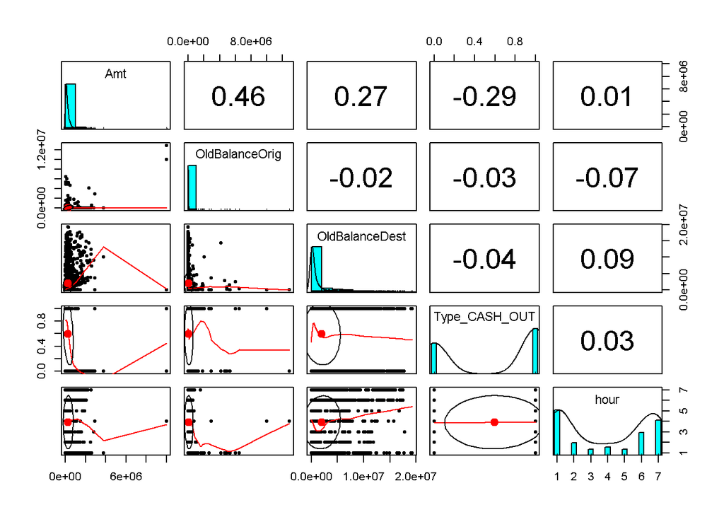

```r
#correlation plot
#pairs.panels(final.rawdata.multc[-c(5)])
samp <- final.rawdata.multc[1:2000,]
pairs.panels(samp[-c(4)])
```

After dropping one of the correlated variables, correlation plot shows no evidence of severe correlation among input variables.

The above correlation plot also shows the distribution of each feature.

```r
#build model after dropping correlated variables
full.corr <- glm(isFraud ~ ., data=final.rawdata.multc, family = "binomial",)
summary(full.corr)
```

```
##
## Call:
## glm(formula = isFraud ~ ., family = "binomial", data = final.rawdata.multc)
##
## Deviance Residuals:
##     Min       1Q   Median       3Q      Max
## -6.0254  -0.0644  -0.0474  -0.0340   7.1362
##
## Coefficients:
##                  Estimate Std. Error z value Pr(>|z|)
## (Intercept)    -3.758e+00  1.150e-01  -32.69   <2e-16 ***
## Amt             6.572e-07  4.713e-08   13.94   <2e-16 ***
## OldBalanceOrig  1.295e-06  3.658e-08   35.42   <2e-16 ***
## OldBalanceDest -6.824e-07  4.383e-08  -15.57   <2e-16 ***
## Type_CASH_OUT  -1.189e+00  7.371e-02  -16.14   <2e-16 ***
## hour           -1.070e-01  7.367e-03  -14.53   <2e-16 ***
## ---
## Signif. codes:  0 '***' 0.001 '**' 0.01 '*' 0.05 '.' 0.1 ' ' 1
##
## (Dispersion parameter for binomial family taken to be 1)
##
##     Null deviance: 15984  on 460393  degrees of freedom
## Residual deviance: 12223  on 460388  degrees of freedom
## AIC: 12235
##
## Number of Fisher Scoring iterations: 11
```

```r
car::vif(full.corr)
```

```
##            Amt OldBalanceOrig OldBalanceDest  Type_CASH_OUT           hour
##       1.344725       1.089119       1.009715       1.311064       1.034455
```

After removing one of the correlated variables, VIF shows no evidence of multicolinearity in the model.

##Detect Outliers

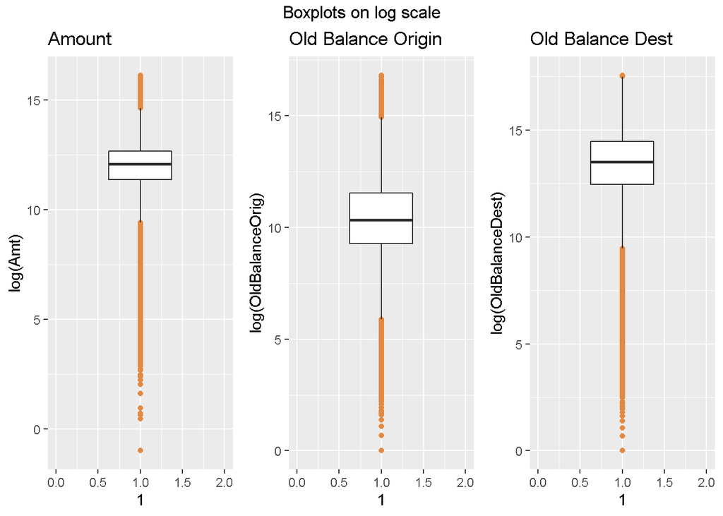

```r
amt.box <- qplot(data=final.rawdata.multc, y=log(Amt), x=1, geom="boxplot", outlier.colour="#E38942", xlim=c(0,2),xlab=NULL,ylab=NULL, main="Amount")

obo.box <- qplot(data=final.rawdata.multc, y=log(OldBalanceOrig), x=1, geom="boxplot", outlier.colour="#E38942", xlim=c(0,2),xlab=NULL,ylab=NULL, main="Old Balance Origin")

obd.box <- qplot(data=final.rawdata.multc, y=log(OldBalanceDest), x=1, geom="boxplot", outlier.colour="#E38942", xlim=c(0,2),xlab=NULL,ylab=NULL, main="Old Balance Dest")

grid.arrange(amt.box,obo.box,obd.box, nrow=1, top="Boxplots on log scale")
```

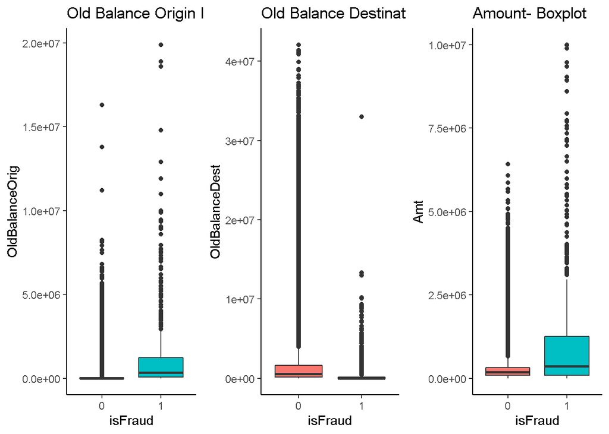

```r
Obo <- ggplot(final.rawdata.multc, aes(x = factor(isFraud) ,y = OldBalanceOrig, fill = factor(isFraud))) +
  geom_boxplot(show.legend = FALSE) +
  labs(title= 'Old Balance Origin Boxplot' , x = 'isFraud') +
  theme_classic()

Obd <- ggplot(final.rawdata.multc, aes(x = factor(isFraud) ,y = OldBalanceDest, fill = factor(isFraud))) +
  geom_boxplot(show.legend = FALSE) +
  labs(title= 'Old Balance Destination Boxplot' , x = 'isFraud') +
  theme_classic()

Amt <- ggplot(final.rawdata.multc, aes(x = isFraud ,y = Amt, fill = factor(isFraud))) +
  geom_boxplot(show.legend = FALSE) +
  labs(title= 'Amount- Boxplot' , x = 'isFraud') +
  theme_classic()

grid.arrange(Obo, Obd, Amt, nrow=1)
```

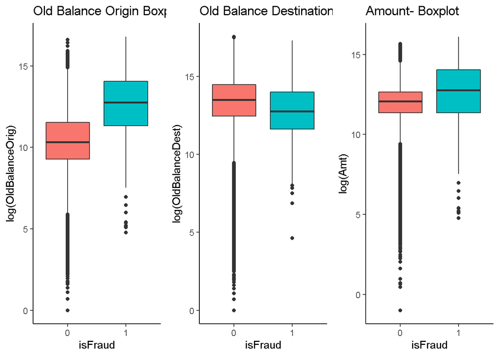

```r
#boxplot on log scale
Obo <- ggplot(final.rawdata.multc, aes(x = factor(isFraud) ,y = log(OldBalanceOrig), fill = factor(isFraud))) +
  geom_boxplot(show.legend = FALSE) +
  labs(title= 'Old Balance Origin Boxplot' , x = 'isFraud') +
  theme_classic()

Obd <- ggplot(final.rawdata.multc, aes(x = factor(isFraud) ,y = log(OldBalanceDest), fill = factor(isFraud))) +
  geom_boxplot(show.legend = FALSE) +
  labs(title= 'Old Balance Destination Boxplot' , x = 'isFraud') +
  theme_classic()

Amt <- ggplot(final.rawdata.multc, aes(x = isFraud ,y = log(Amt), fill = factor(isFraud))) +
  geom_boxplot(show.legend = FALSE) +
  labs(title= 'Amount- Boxplot' , x = 'isFraud') +
  theme_classic()

grid.arrange(Obo, Obd, Amt, nrow=1)
```

View the dispersion of the data depending on the isFraud feature. At first glance, the number of fraudulent transactions in the Amount feature appears to be more and have a larger variance. The above boxplots show there are extreme outliers in the above features.

```r
#split dataset
set.seed(3333)
ind <- sample(2, nrow(final.rawdata.multc), replace = T, prob = c(.7,.3))

train <- final.rawdata.multc[ind==1,]
test <- final.rawdata.multc[ind==2,]

dim(train)
```

```
## [1] 322236      6
```

```r
dim(test)
```

```
## [1] 138158      6
```

```r
#Structure of train dataset
str(train)
```

```
## 'data.frame':    322236 obs. of  6 variables:
##  $ Amt           : num  181 229134 311686 110415 56954 ...
##  $ OldBalanceOrig: num  181 15325 10835 26845 1942 ...
##  $ OldBalanceDest: num  21182 5083 6267 288800 70253 ...
##  $ isFraud       : Factor w/ 2 levels "0","1": 2 1 1 1 1 1 1 1 1 1 ...
##  $ Type_CASH_OUT : int  1 1 0 1 1 1 0 1 1 1 ...
##  $ hour          : num  1 1 1 1 1 1 1 1 1 1 ...
```

```r
#develop model on train dataset
fit <- glm(isFraud ~ ., data=train, family = "binomial")
summary(fit)
```

```
##
## Call:
## glm(formula = isFraud ~ ., family = "binomial", data = train)
##
## Deviance Residuals:
##     Min       1Q   Median       3Q      Max
## -5.0553  -0.0628  -0.0463  -0.0317   7.6327
##
## Coefficients:
##                  Estimate Std. Error z value Pr(>|z|)
## (Intercept)    -3.785e+00  1.393e-01  -27.17   <2e-16 ***
## Amt             6.595e-07  5.674e-08   11.62   <2e-16 ***
## OldBalanceOrig  1.399e-06  4.421e-08   31.65   <2e-16 ***
## OldBalanceDest -7.982e-07  5.812e-08  -13.73   <2e-16 ***
## Type_CASH_OUT  -1.261e+00  8.869e-02  -14.21   <2e-16 ***
## hour           -1.009e-01  8.908e-03  -11.33   <2e-16 ***
## ---
## Signif. codes:  0 '***' 0.001 '**' 0.01 '*' 0.05 '.' 0.1 ' ' 1
##
## (Dispersion parameter for binomial family taken to be 1)
##
##     Null deviance: 11255.4  on 322235  degrees of freedom
## Residual deviance:  8362.8  on 322230  degrees of freedom
## AIC: 8374.8
##
## Number of Fisher Scoring iterations: 11
```

Interpretation of the model:

Each regression coefficient in the model is statistically significant.

Now can see that the log(odds) of isFraud are increased by a factor of increase in Amt (holding other input variables constant).

The log(odds) of isFraud increase with Amt and OldBalanceOrig and decrease with OldBalanceDest, Type_CASH_OUT and hour.

In other words, the more the amount in old balance orig the more the chance of occurring fraud. And the lesser the old balance dest, the more the chance of occurring fraud.

For Type_Cash_Out feature, the lesser the customer uses cash_out type transaction, the more the chance of occurring fraud.

For hour feature, as the hours gets decreased from 24 hrs to 0 hrs, there is high chance of occurring fraud. Further this was noted in the earlier EDA that fraud transactions took place throughout the clock.

#Feature engineering

```r
#variable importance
varimp <- varImp(fit)
varimp <- data.frame(Variables = rownames(varimp), varimp, row.names = NULL)
varimp %>% arrange(desc(Overall))
```

```
##        Variables  Overall
## 1 OldBalanceOrig 31.64885
## 2  Type_CASH_OUT 14.21269
## 3 OldBalanceDest 13.73261
## 4            Amt 11.62387
## 5           hour 11.32647
```

As per the above model, feature importance summary shows ‘OldBalanceOrig’ variable is the most important variable which contributing significantly in predicting fraud cases followed by rest of the variables in the model.

Let’s perform statistical test on features.

```r
#Anova test
anova(fit, test = 'Chisq')
```

```
## Analysis of Deviance Table
##
## Model: binomial, link: logit
##
## Response: isFraud
##
## Terms added sequentially (first to last)
##
##
##                Df Deviance Resid. Df Resid. Dev  Pr(>Chi)
## NULL                          322235    11255.4
## Amt             1  1301.21    322234     9954.2 < 2.2e-16 ***
## OldBalanceOrig  1   877.77    322233     9076.4 < 2.2e-16 ***
## OldBalanceDest  1   395.75    322232     8680.7 < 2.2e-16 ***
## Type_CASH_OUT   1   194.80    322231     8485.9 < 2.2e-16 ***
## hour            1   123.05    322230     8362.8 < 2.2e-16 ***
## ---
## Signif. codes:  0 '***' 0.001 '**' 0.01 '*' 0.05 '.' 0.1 ' ' 1
```

Anova suggests all the features in the model are significantly contributing in predicting fraud cases.

```r
#backward selection method
stfit <- step(glm(isFraud ~ ., data=train, family = "binomial"), direction='backward')
```

```
## Start:  AIC=8374.85
## isFraud ~ Amt + OldBalanceOrig + OldBalanceDest + Type_CASH_OUT +
##     hour
```

```
##                  Df Deviance    AIC
## <none>                8362.8 8374.8
## - Amt             1   8485.2 8495.2
## - hour            1   8485.9 8495.9
## - Type_CASH_OUT   1   8547.5 8557.5
## - OldBalanceDest  1   8781.3 8791.3
## - OldBalanceOrig  1   9206.0 9216.0
```

The above backward feature selection suggests that if Amt feature was dropped from the model, the AIC would be increased to 8495.2 which is more than the AIC value of 8374.85 which is not good so we cannot drop this feature. Overall, we can see all the AIC values were increased with the drop of each feature from the model. So we cannot drop any feature from the model.

```r
#forward selection method
stfit <- step(glm(isFraud~1, data=train, family = "binomial"), direction='forward', scope = ~OldBalanceOrig+OldBalanceDest+Type_CASH_OUT+hour+Amt)
```

```
## Start:  AIC=11257.42
## isFraud ~ 1
```

```
##                  Df Deviance     AIC
## + OldBalanceOrig  1   9396.3  9400.3
## + Amt             1   9954.2  9958.2
## + Type_CASH_OUT   1  10835.8 10839.8
## + hour            1  10902.6 10906.6
## + OldBalanceDest  1  10915.3 10919.3
## <none>               11255.4 11257.4
##
## Step:  AIC=9400.28
## isFraud ~ OldBalanceOrig
```

```
##                  Df Deviance    AIC
## + Type_CASH_OUT   1   9026.1 9032.1
## + OldBalanceDest  1   9071.2 9077.2
## + Amt             1   9076.4 9082.4
## + hour            1   9226.9 9232.9
## <none>                9396.3 9400.3
##
## Step:  AIC=9032.13
## isFraud ~ OldBalanceOrig + Type_CASH_OUT
```

```
##                  Df Deviance    AIC
## + OldBalanceDest  1   8638.4 8646.4
## + hour            1   8874.9 8882.9
## + Amt             1   8919.1 8927.1
## <none>                9026.1 9032.1
```

```
##
## Step:  AIC=8646.37
## isFraud ~ OldBalanceOrig + Type_CASH_OUT + OldBalanceDest
```

```
##        Df Deviance    AIC
## + hour  1   8485.2 8495.2
## + Amt   1   8485.9 8495.9
## <none>      8638.4 8646.4
```

```
##
## Step:  AIC=8495.24
## isFraud ~ OldBalanceOrig + Type_CASH_OUT + OldBalanceDest + hour
```

```
##        Df Deviance    AIC
## + Amt   1   8362.8 8374.8
## <none>      8485.2 8495.2
```

```
##
## Step:  AIC=8374.85
## isFraud ~ OldBalanceOrig + Type_CASH_OUT + OldBalanceDest + hour +
##     Amt
```

```r
#stepwise selection method
stfit <- step(glm(isFraud ~ ., data=train, family = "binomial"), direction='both')
```

```
## Start:  AIC=8374.85
## isFraud ~ Amt + OldBalanceOrig + OldBalanceDest + Type_CASH_OUT +
##     hour
```

```
##                  Df Deviance    AIC
## <none>                8362.8 8374.8
## - Amt             1   8485.2 8495.2
## - hour            1   8485.9 8495.9
## - Type_CASH_OUT   1   8547.5 8557.5
## - OldBalanceDest  1   8781.3 8791.3
## - OldBalanceOrig  1   9206.0 9216.0
```

Further both forward and stepwise selections also suggest model with all features is significant per AIC value.

##Binomial regression assumptions – 1. Linearity assumption 2. No highly influential observations or outliers 3. No multicollinearity 4. No missing values 5. No class imbalance

#Linearity assumption - Here, will check the linear relationship between continuous predictors and the logit of the outcome.

```r
#predict probabilities
pred_prob <- predict(fit, train, type = 'response')

library(tidyverse)
library(broom)
theme_set(theme_classic())

#select numeric variable
num.train <- train %>%
  dplyr::select_if(is.numeric)

predictors <- colnames(num.train)

# Bind the logit and tidying the data for plot
newdata <- num.train %>%
  mutate(logit = log(pred_prob/(1-pred_prob))) %>%
  gather(key = "predictors", value = "predictor.value", -logit)

#ggplot(mydata, aes(logit, predictor.value))+
  #geom_point(size = 0.5, alpha = 0.5) +
  #geom_smooth(method = "loess") +
  #theme_bw() +
  #facet_wrap(~predictors, scales = "free_y")
```

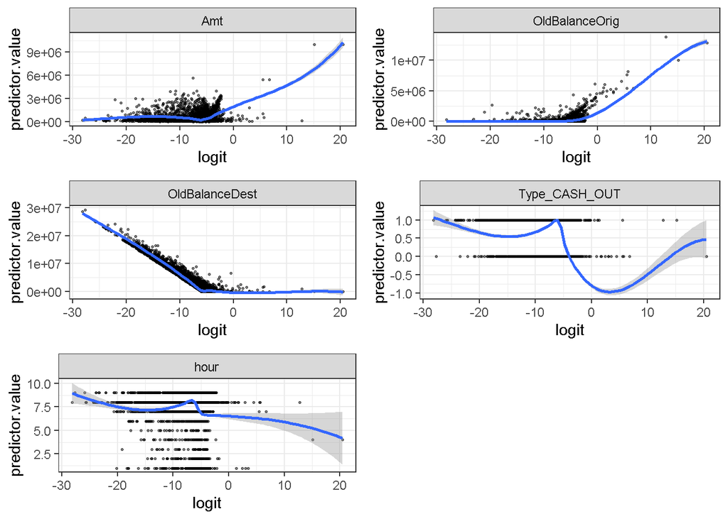

```r
##Reducing the data size as it was taking long time to run the code.
Amt        <- newdata %>% filter(predictors=='Amt')
OldBalOrig <- newdata %>% filter(predictors=='OldBalanceOrig')
OldBalDest <- newdata %>% filter(predictors=='OldBalanceDest')
Cash_Out   <- newdata %>% filter(predictors=='Type_CASH_OUT')
hour       <- newdata %>% filter(predictors=='hour')

AmtPlot <- ggplot(Amt[1:10000,], aes(logit, predictor.value))+
  geom_point(size = 0.5, alpha = 0.5) +
  geom_smooth(method = "loess") +
  theme_bw() +
  facet_wrap(~predictors, scales = "free_y")

OboPlot <- ggplot(OldBalOrig[1:10000,], aes(logit, predictor.value))+
  geom_point(size = 0.5, alpha = 0.5) +
  geom_smooth(method = "loess") +
  theme_bw() +
  facet_wrap(~predictors, scales = "free_y")

ObdPlot <- ggplot(OldBalDest[1:10000,], aes(logit, predictor.value))+
  geom_point(size = 0.5, alpha = 0.5) +
  geom_smooth(method = "loess") +
  theme_bw() +
  facet_wrap(~predictors, scales = "free_y")

CashPlot <- ggplot(Cash_Out[1:10000,], aes(logit, predictor.value))+
  geom_point(size = 0.5, alpha = 0.5) +
  geom_smooth(method = "loess") +
  theme_bw() +
  facet_wrap(~predictors, scales = "free_y")

HrPlot <- ggplot(hour[1:10000,], aes(logit, predictor.value))+
  geom_point(size = 0.5, alpha = 0.5) +
  geom_smooth(method = "loess") +
  theme_bw() +
  facet_wrap(~predictors, scales = "free_y")

#Linearity plot
grid.arrange(AmtPlot, OboPlot, ObdPlot, CashPlot,HrPlot, ncol=2)
```

Note: Reduced the data size as it was taking long time to run the code.

The smoothed scatter plots on partial data showed that variable OldBalanceDest has some negative linear association with the fraud outcome in logit scale. The rest of the variables are not linear and might need some data transformation.

If the scatter plot shows non-linearity, need other methods to build the model such as transformation of data.

#influential values - Influential values are extreme individual data points that can alter the quality of the regression model.

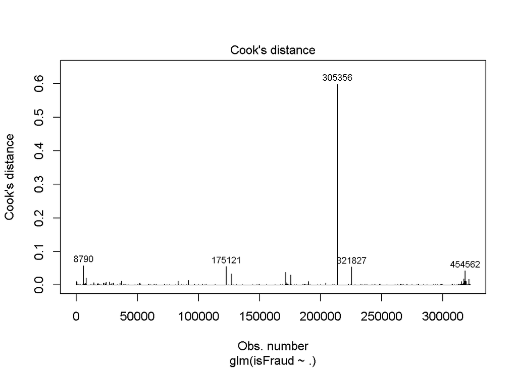

```r
#Cook's distance
#Here we label the top 3 largest values
plot(fit, which = 4, id.n = 5)
```

Note: Not all outliers are influential observations.

```r
# Extract model results
fit.data <- augment(fit) %>%
  mutate(index = 1:n())

fit.data %>% top_n(5, .cooksd)
```

```
## # A tibble: 5 x 15
##   .rownames isFraud    Amt OldBalanceOrig OldBalanceDest Type_CASH_OUT
##   <chr>     <fct>    <dbl>          <dbl>          <dbl>         <int>
## 1 8790      0       1.22e5      13800000         948589.             1
## 2 175121    1       2.96e5        295664.      10200000              1
## 3 305356    1       1.68e6       1684039.      33000000              1
## 4 321827    1       5.04e5        503793.      10100000              1
## 5 454562    1       3.61e6       3607918.       8391754.             1
## # ... with 9 more variables: hour <dbl>, .fitted <dbl>, .se.fit <dbl>,
## #   .resid <dbl>, .hat <dbl>, .sigma <dbl>, .cooksd <dbl>,
## #   .std.resid <dbl>, index <int>
```

As per Cook’s plot, the top 5 highly influential observations in the model.

```r
#find total number of highly influential observations
fit.data %>%
  filter(abs(.std.resid) > 3)
```

```
## # A tibble: 432 x 15
##    .rownames isFraud    Amt OldBalanceOrig OldBalanceDest Type_CASH_OUT
##    <chr>     <fct>    <dbl>          <dbl>          <dbl>         <int>
##  1 2         1       1.81e2           181          21182              1
##  2 125       1       2.81e3          2806          26202              1
##  3 194       1       2.01e4         20128           6268              1
##  4 348       1       3.51e4         35064.         31140              1
##  5 535       1       2.51e4         25071.          9084.             1
##  6 552       1       1.33e5          4499.             0              1
##  7 605       1       2.35e5        235239.             0              1
##  8 847       1       1.86e4         18627.        147252.             1
##  9 882       1       1.05e4         10539.             0              1
## 10 1007      1       1.70e5        169942.             0              1
## # ... with 422 more rows, and 9 more variables: hour <dbl>, .fitted <dbl>,
## #   .se.fit <dbl>, .resid <dbl>, .hat <dbl>, .sigma <dbl>, .cooksd <dbl>,
## #   .std.resid <dbl>, index <int>
```

There are about 432 influential observations in the train dataset.

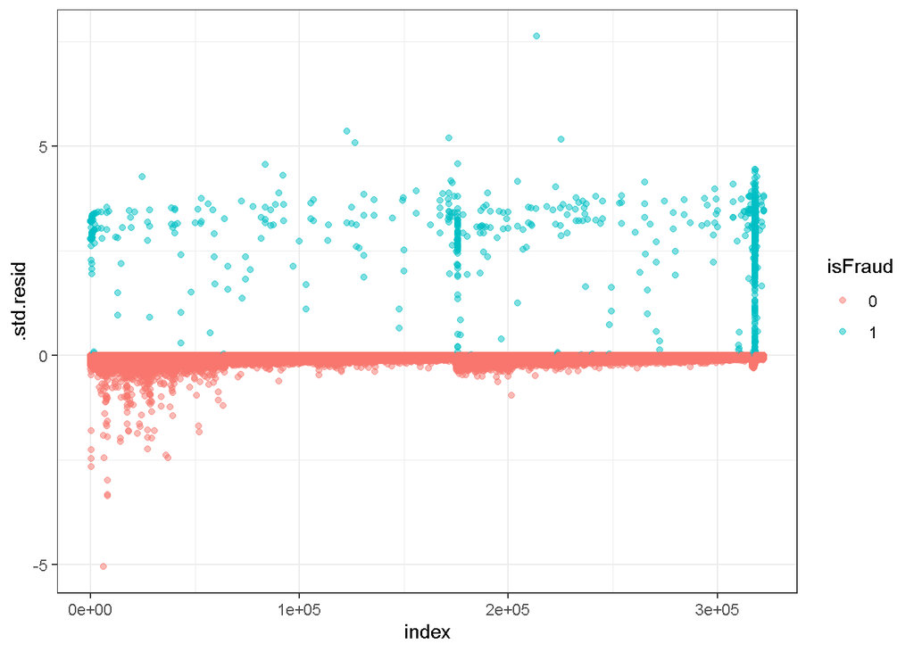

```r
#Plot the standardized residuals
ggplot(fit.data, aes(index, .std.resid)) +
  geom_point(aes(color = isFraud), alpha = .5) +
  theme_bw()
```

The above standardized residual plot also shows there are extreme outliers in the model.

When the dataset has outliers in a continuous predictor, potential solutions include: 1. Robust logistic regression can be helpful when fitting logistic regression models to data containing outliers and influential observations 2. Removing the concerned records from the model 3. Transform the data 4. Use non-parametric methods

##Multicollinearity

```r
car::vif(fit)
```

```
##            Amt OldBalanceOrig OldBalanceDest  Type_CASH_OUT           hour
##       1.340783       1.094897       1.009367       1.313008       1.036029
```

As we earlier removed the correlated variable, there is no evidence of multicollinearity in the model.

#Goodness-of-fit test – Another approach to determine whether or not the above model is statistically fit is through goodness-of-fit test. It examines whether the observed proportions of events are similar to the predicted probabilities of occurence in subgroups of the data set using a pearson chi-square test.

```r
#Homer-Lemeshow statistical test
library(generalhoslem)
logitgof(train$isFraud, fitted(fit))
```

```
##
##  Hosmer and Lemeshow test (binary model)
##
## data:  train$isFraud, fitted(fit)
## X-squared = 193.38, df = 8, p-value < 2.2e-16
```

The goodness-of-fit test rejected the null hypothesis. Hence there is enough evidence that the above model is not statistically fit.

##Pseudo R^2 – Unlike linear regression with OLS estimation, there is no R^2 statistic which explains the proportion of variance in the dependent variable that is explained by the predictors. However, there are a number of pseudo R2 metrics that could be of value.

```r
#Pseudo R^2
library(pscl)
round(pR2(fit),3)
```

```
##       llh   llhNull        G2  McFadden      r2ML      r2CU
## -4181.423 -5627.712  2892.579     0.257     0.009     0.260
```

The independent variables in the above model are able to explain only 25.7% of the dependent variable (fraud cases) which is very poor.

Will make predictions on the above model.

#Predictions

```r
#predictions on train dataset
pred_prob <- predict(fit, train, type = 'response')

#first 6 predicted probabilities
head(pred_prob)
```

```
##           2           3           5           6           7           9
## 0.005690212 0.006838919 0.024830700 0.005133119 0.005694403 0.005920395
```

```r
#setting 0.5 as threshold value for predictions
pred_class <- ifelse(pred_prob>.5,1,0)

#predict first 6 observations with 0.5 threshold value
head(pred_class)
```

```
## 2 3 5 6 7 9
## 0 0 0 0 0 0
```

```r
#setting 0.5 as threshold value for predictions
pred_class <- ifelse(pred_prob>.5,1,0)

#predict first 6 observations with 0.5 threshold value
head(pred_class)
```

```
## 2 3 5 6 7 9
## 0 0 0 0 0 0
```

```r
#Confusion matrix on the train dataset
confusionMatrix(as.factor(pred_class), as.factor(train$isFraud), positive = '1')
```

```
## Confusion Matrix and Statistics
##
##           Reference
## Prediction      0      1
##          0 321391    694
##          1     40    111
##
##                Accuracy : 0.9977
##                  95% CI : (0.9976, 0.9979)
##     No Information Rate : 0.9975
##     P-Value [Acc > NIR] : 0.005875
##
##                   Kappa : 0.2316
##
##  Mcnemar's Test P-Value : < 2.2e-16
##
##             Sensitivity : 0.1378882
##             Specificity : 0.9998756
##          Pos Pred Value : 0.7350993
##          Neg Pred Value : 0.9978453
##              Prevalence : 0.0024982
##          Detection Rate : 0.0003445
##    Detection Prevalence : 0.0004686
##       Balanced Accuracy : 0.5688819
##
##        'Positive' Class : 1
##
```

The interpretation of the confusion matrix is that there were about 321391 records belonged to legitimate class and the model also predicted them as non-fraudulent records which is correct prediction for class 0.

In actual there were 40 records which were belonged to non-fraudulent records but the model predicted these 40 records as fraudulent records which is incorrect prediction by the model for class 0. And 694 records were actually belonged to fraud records, but the model predicted these 694 records as non-fraudulent records which is incorrect prediction for class 1.

In terms of overall accuracy, the above model has done pretty well with 99.8% which is good.

One thing we need to notice very closely in the above confusion matrix is that the model predicted legitimate records more accurately which is almost 100% than fraudulent records which is just 13.8%. In other words, the model has done pretty well in predicting non-fraudulent cases, but failed in more accurately predicting fraudulent transactions.

This is because of class imbalance in the data. As we have seen above that the dataset has higher number of records for legitimate records with 321431 in comparison to fraudulent records which are only 805. Hence the non-fraudlent records being the higher class in the given dataset is dominating the whole show in this prediction model. In such scenario, we cannot build model based on accuracy metric.

As our primary area of focus in building the above model is to predict fraudulent cases more accurately than non-fraudulent cases, then sensitivity and specificity comes into picture.

One way to overcome this issue is through ROC curve.

#Accuracy plot

```r
library(ROCR)
```

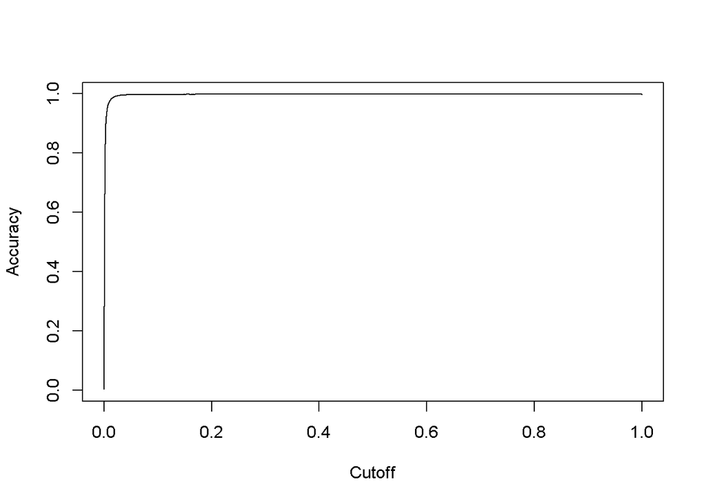

```r
pred <- prediction(pred_prob, train$isFraud)
eval <- performance(pred, "acc")
plot(eval)
```

The plot shows cutoff values from 0 to 1 and for different cut-off values, what is the accuracy the model achieves. This accuracy is overall accuracy in the model.

We can see in the plot that when the cutoff value is approximately 0.01 the accuracy is almost 100%. In the model, the accuracy seems to be constant throughout with different cutoff values which is because of class imbalance.

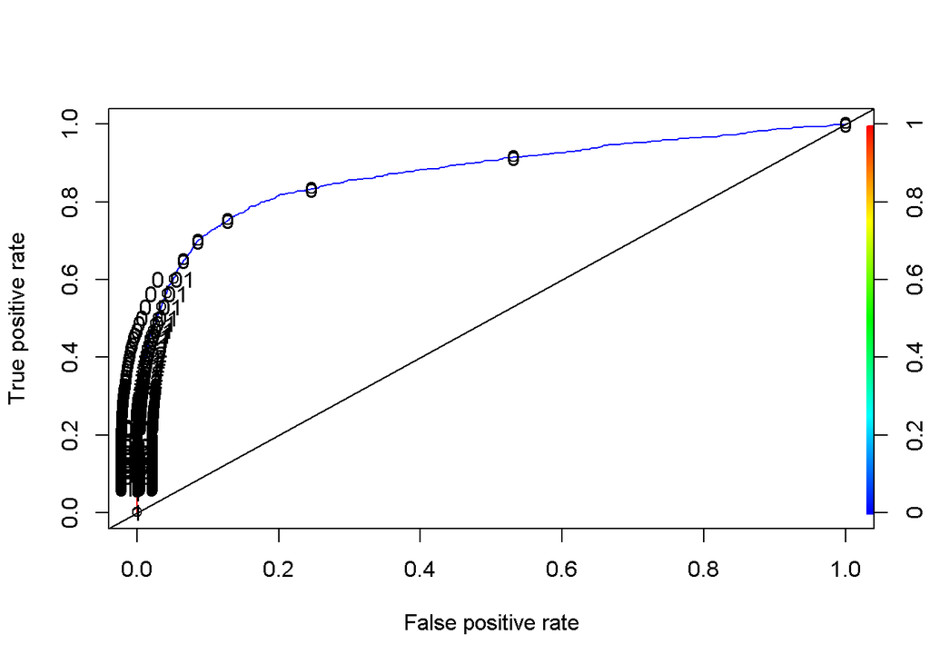

```r
#ROC Curve
library(ROCR)
pred <- prediction(pred_prob, train$isFraud)
perf <- performance(pred, "tpr","fpr")

#ROC plot
plot(perf, colorize=TRUE, print.cutoffs.at=seq(0,1,0.001))
abline(a=0,b=1)
```

ROC plot shows how the model is performing against the benchmark.

```r
#AUC on the train dataset
#pred_prob <- predict(fit, train, type = 'response')
#pred_class <- ifelse(pred_prob>.5,1,0)

pred <- prediction(pred_prob, train$isFraud)
perf <- performance(pred, "tpr","fpr")

auc <- performance(pred, measure = "auc")
auc <- auc@y.values[[1]]
auc
```

```
## [1] 0.8725279
```

Model achieved 87.3% area under curve on the train data.

```r
#predicted values with 0.1 cutoff value
pred_class_.1 <- ifelse(pred_prob>.1,1,0)

library(caret)
#Confusion matrix
confusionMatrix(as.factor(pred_class_.1), as.factor(train$isFraud), positive = '1')
```

```
## Confusion Matrix and Statistics
##
##           Reference
## Prediction      0      1
##          0 321231    629
##          1    200    176
##
##                Accuracy : 0.9974
##                  95% CI : (0.9972, 0.9976)
##     No Information Rate : 0.9975
##     P-Value [Acc > NIR] : 0.8068
##
##                   Kappa : 0.2969
##
##  Mcnemar's Test P-Value : <2e-16
##
##             Sensitivity : 0.2186335
##             Specificity : 0.9993778
##          Pos Pred Value : 0.4680851
##          Neg Pred Value : 0.9980457
##              Prevalence : 0.0024982
##          Detection Rate : 0.0005462
##    Detection Prevalence : 0.0011668
##       Balanced Accuracy : 0.6090057
##
##        'Positive' Class : 1
##
```

Now we can see some improvement in sensitivity with 21.9% as it was earlier at 13.8%.

The overall accuracy in the model with 0.1 threshold is at 99.7%.

Let’s try one more threshold value.

```r
#predicted values with .005 cutoff value
pred_class_.005 <- ifelse(pred_prob>.005,1,0)

#Confusion matrix
confusionMatrix(as.factor(pred_class_.005), as.factor(train$isFraud), positive = '1')
```

```
## Confusion Matrix and Statistics
##
##           Reference
## Prediction      0      1
##          0 300212    282
##          1  21219    523
##
##                Accuracy : 0.9333
##                  95% CI : (0.9324, 0.9341)
##     No Information Rate : 0.9975
##     P-Value [Acc > NIR] : 1
##
##                   Kappa : 0.0418
##
##  Mcnemar's Test P-Value : <2e-16
##
##             Sensitivity : 0.649689
##             Specificity : 0.933986
##          Pos Pred Value : 0.024055
##          Neg Pred Value : 0.999062
##              Prevalence : 0.002498
##          Detection Rate : 0.001623
##    Detection Prevalence : 0.067472
##       Balanced Accuracy : 0.791838
##
##        'Positive' Class : 1
##
```

Note: As we try to increase the sensitivity, the specificity gets decreased.

#Predictions on test dataset

```r
#predictions on test dataset with 0.005 threshold value
test_prob <- predict(fit, test, type = 'response')
test_class_.005 <- ifelse(test_prob >0.005,1,0)

#Confusion matrix
confusionMatrix(as.factor(test_class_.005), as.factor(test$isFraud))
```

```
## Confusion Matrix and Statistics
##
##           Reference
## Prediction      0      1
##          0 128748    133
##          1   9073    204
##
##                Accuracy : 0.9334
##                  95% CI : (0.932, 0.9347)
##     No Information Rate : 0.9976
##     P-Value [Acc > NIR] : 1
##
##                   Kappa : 0.0379
##
##  Mcnemar's Test P-Value : <2e-16
##
##             Sensitivity : 0.93417
##             Specificity : 0.60534
##          Pos Pred Value : 0.99897
##          Neg Pred Value : 0.02199
##              Prevalence : 0.99756
##          Detection Rate : 0.93189
##    Detection Prevalence : 0.93285
##       Balanced Accuracy : 0.76975
##
##        'Positive' Class : 0
##
```

With 0.005 threshold value, the model has achieved 93.3% overall accuracy with sensitivity 60.5% and specificity 93.4% on the test dataset.

[figure not shown]

```r
#ROC curve on the test dataset

#predictions on test dataset
#test_prob <- predict(fit, test, type = 'response')
#test_class_.005 <- ifelse(test_prob > 0.005,1,0)

test_pred <- prediction(test_prob, test$isFraud)
test_roc <- performance(test_pred, "tpr","fpr")

#ROC plot
plot(test_roc, colorize=TRUE, main='Area Under Curve on the test dataset')
abline(a=0,b=1)

#AUC
test_auc <- performance(pred,"auc")

test.auc.value <- unlist(slot(test_auc, "y.values"))
test.auc.value <- round(test.auc.value, 4)
legend(.6,.4,test.auc.value, cex=1, title = "AUC")
```

Another way to use the ROC curve is to calculcate area under the curve. Visually we can see the curve is doing better than the benchmark and if the area is higher means model performance is better.

```r
library(pROC)
#Compute AUC for prediction with the OldBalanceOrig variable
f1 <- roc(isFraud ~ OldBalanceOrig, data=train)
```

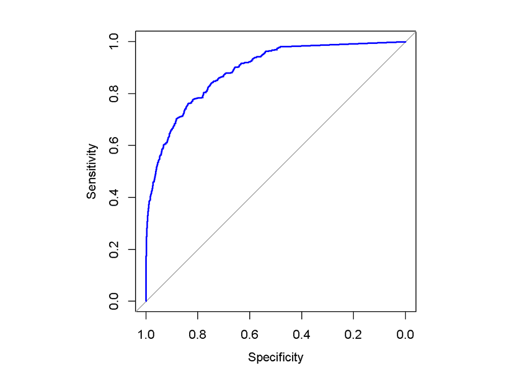

```r
opar <- par(no.readonly = TRUE)
par(pty='s')
plot(f1, col="blue")
```

```r
par(opar)
```

```r
#Compute AUC for prediction with the Amt variable
f2 <- roc(isFraud ~ Amt, data=train)
```

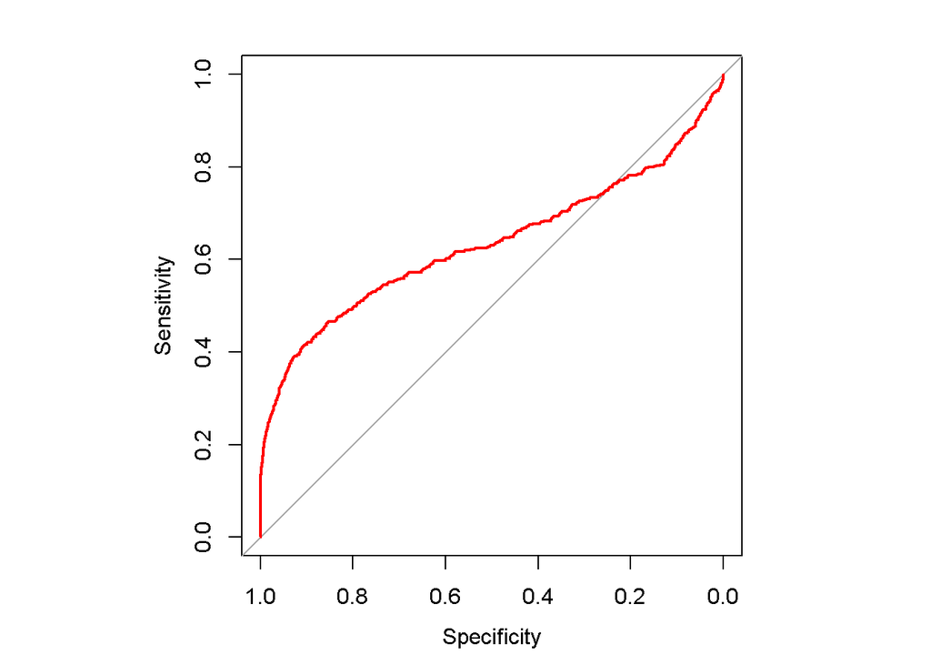

```r
opar <- par(no.readonly = TRUE)
par(pty='s')
plot(f2, col="red")
```

```r
par(opar)
```

```r
#Compute AUC for prediction with the OldBalanceDest variable
f2 <- roc(isFraud ~ OldBalanceDest, data=train)
```

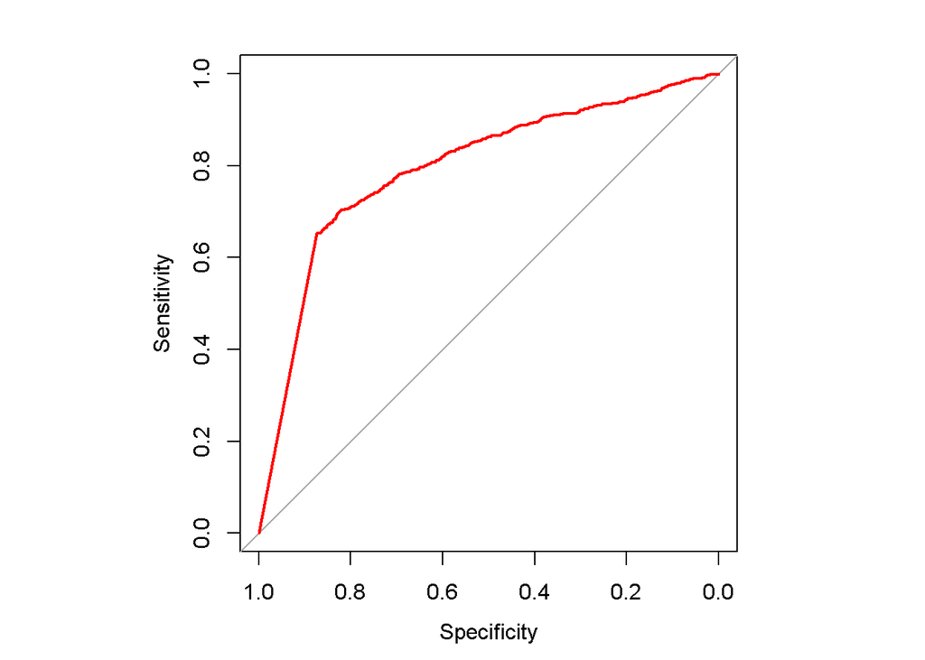

```r
opar <- par(no.readonly = TRUE)
par(pty='s')
plot(f2, col="red")
```

```r
par(opar)
```

```r
#Compute AUC for prediction with the Type_CASH_OUT variable
f2 <- roc(isFraud ~ Type_CASH_OUT, data=train)
```

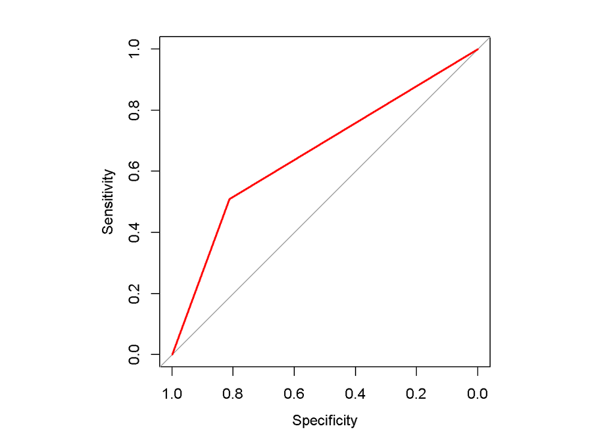

```r
opar <- par(no.readonly = TRUE)
par(pty='s')
plot(f2, col="red")
```

```r
par(opar)
```

```r
#Compute AUC for prediction with the hour variable
f2 <- roc(isFraud ~ hour, data=train)
```

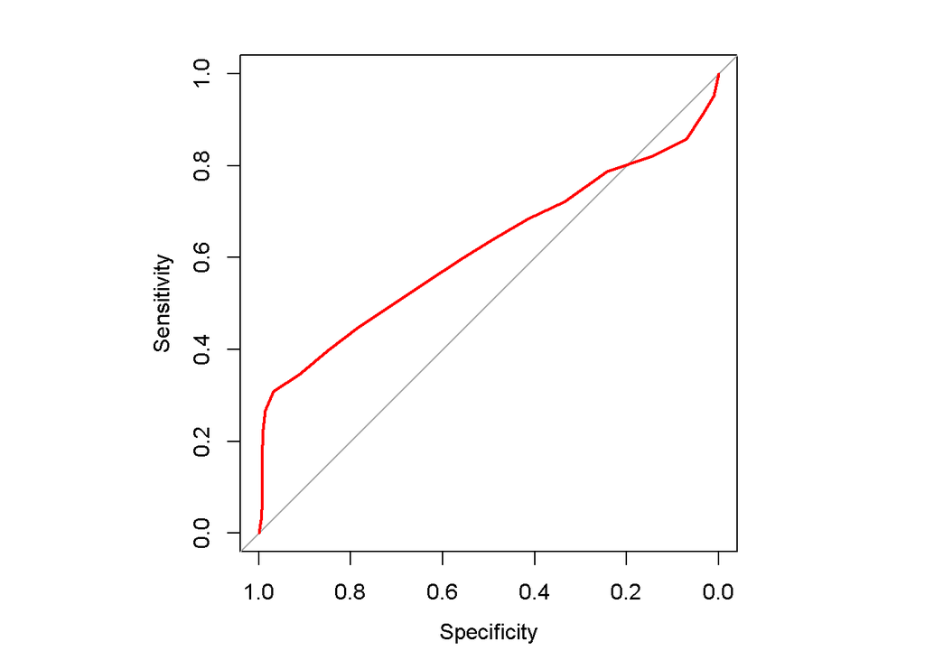

```r
opar <- par(no.readonly = TRUE)
par(pty='s')
plot(f2, col="red")
```

```r
par(opar)
```

How the model is performing with each feature with respect to their respective benchmarks.